# Assignment 2

Michael Pimentel-Galvan

11/5/2020

```r
knitr::opts_chunk$set(echo = TRUE, warning = F, message = F)
```

```r
library(tidyverse)
library(plotly)
library(sf)
library(tigris)
library(leaflet)
library(censusapi)
library(tidycensus)
library(readr)
library(finalfit)
library(dplyr)
library(knitr)

Sys.setenv(CENSUS_KEY="c8aa67e4086b4b5ce3a8717f59faa9a28f611dab")
```

1. An equity analysis of educational attainment by race. Plot the “stacked” and “filled” bar charts as demonstrated in 2.2; from there, you are welcome to add as many comments and supplementary visualizations as you’d like. Essentially, respond to the question: “Is there disproportionate education attainment by race in the County?” Note that the universe of the ACS datasets on educational attainment is “population 25 years or older”, so be sure to clarify that in your visuals and commentary.

Education by Race code:

```r
acs_vars_2018_5yr <-
  listCensusMetadata(
    name = "2018/acs/acs5",
    type = "variables"
  )

census_race_labels <-
  c(
    "White Alone",
    "Black or African American",
    "American Indian and Alaska Native Alone",
    "Asian Alone",
    "Native Hawaiian and Other Pacific Islander Alone)",
    "Some Other Race Alone",
    "Two or More Races"
  )
bay_Education_race <-
  1:7 %>%
  map_dfr(function(x){
    getCensus(
      name = "acs/acs5",
      vintage = 2018,
      region = "county:085",
      regionin = "state:06",
      vars = paste0("group(C15002",LETTERS[x],")")
    ) %>%
      select(!c(GEO_ID,state,NAME) & !ends_with(c("EA","MA","M"))) %>%
      pivot_longer(
        ends_with("E"),
        names_to = "variable",
        values_to = "estimate"
      ) %>%
      left_join(
        acs_vars_2018_5yr %>%
          select(name, label),
        by = c("variable" = "name")
      ) %>%
      select(-variable) %>%
      separate(
        label,
        into = c(NA,NA,NA,"Edu"),
        sep = "!!"
      ) %>%
      filter(!is.na(Edu)) %>%
      mutate(race = census_race_labels[x])
  })
eduGroup<- group_by(bay_Education_race,Edu,race)
eduSum<-summarize(eduGroup,TOTAL= sum(estimate, na.rm = T))
```

Stacked Bar plot Code:

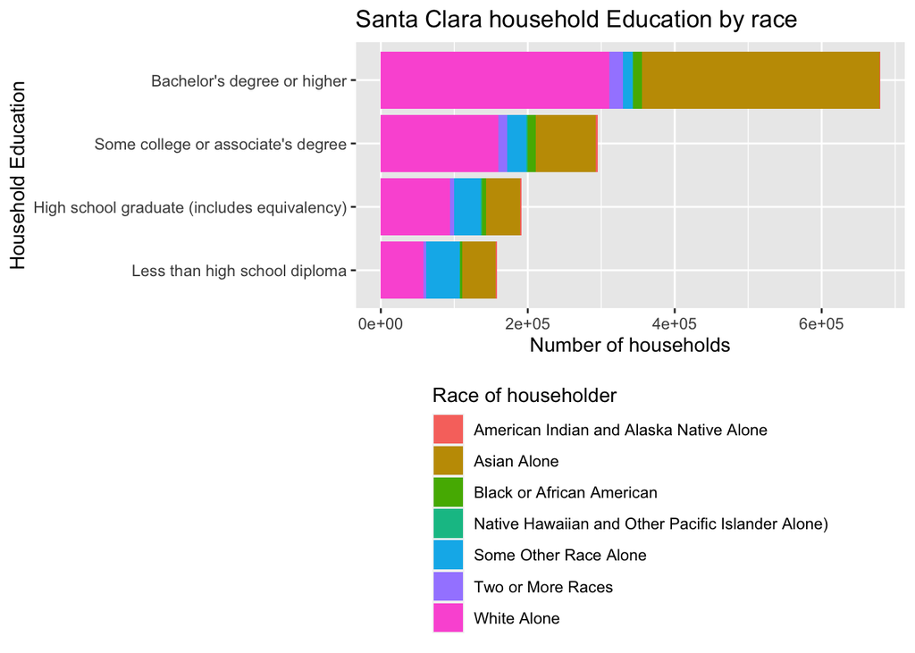

```r
#Stacked Plot
eduSum %>%
  group_by(Edu, race) %>%
  summarize(TOTAL= sum(TOTAL)) %>%
  ggplot() +
  geom_bar(
    aes(
      x = Edu %>% factor(levels = bay_Education_race$Edu[1:4]),
      y = TOTAL,
      fill = race
    ),
    stat = "identity",
    position = "stack"
  ) +
  labs(
    x = "Household Education",
    y = "Number of households",
    title = "Santa Clara household Education by race",
    fill = "Race of householder"
  )+
  coord_flip()+
  theme(
    legend.position = "bottom",
    legend.direction = "vertical"
  )
```

Filled Bar plot Code:

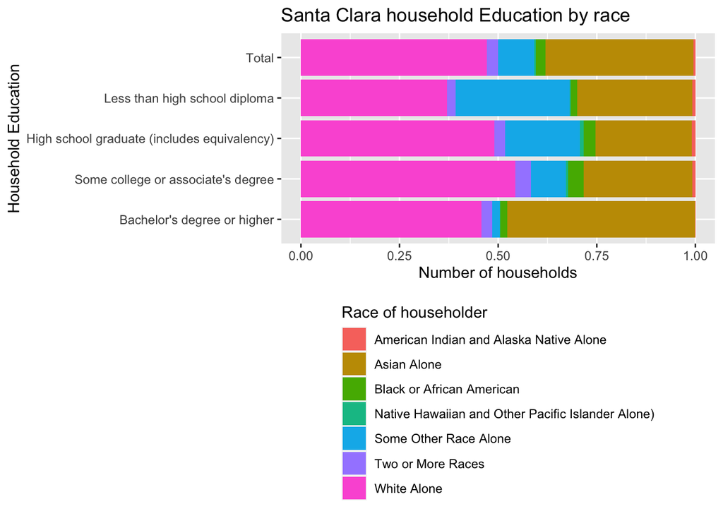

```r
#Filled Plot
raceSum<-
  eduSum%>%
  group_by(race) %>%
  summarize(TOTAL = sum(TOTAL)) %>%
  mutate(Edu = "Total")

eduSum %>%
  group_by(Edu, race) %>%
  summarize(TOTAL= sum(TOTAL)) %>%
  rbind(raceSum) %>%
  ggplot() +
  geom_bar(
    aes(
      x = Edu %>% factor(levels = rev(c("Total",bay_Education_race$Edu[1:4]))),
      y = TOTAL,
      fill = race
    ),
    stat = "identity",
    position = "fill"
  ) +
  labs(
    x = "Household Education",
    y = "Number of households",
    title = "Santa Clara household Education by race",
    fill = "Race of householder"
  )+
  coord_flip()+
  theme(
    legend.position = "bottom",
    legend.direction = "vertical"
  )
```

Analysis Code:

```r
((sum(raceSum$TOTAL[1:6])/sum(raceSum$TOTAL))*100) %>% round()
```

```
## [1] 53
```

```r
((eduSum %>%
    filter(Edu %in% eduSum$Edu[1:5]) %>%
    filter(race != "White Alone") %>%
    pull(TOTAL) %>%
    sum()) /
    (eduSum %>%
       filter(Edu %in% eduSum$Edu[1:5]) %>%
       pull(TOTAL) %>%
       sum()) * 100) %>%
  round()
```

```
## [1] 54
```

```r
((((eduSum %>%
      filter(Edu %in% eduSum$Edu[1:5]) %>%
      filter(race != "White Alone") %>%
      pull(TOTAL) %>%
      sum()) /
     (eduSum  %>%
        filter(Edu %in% eduSum$Edu[1:5]) %>%
        pull(TOTAL) %>%
        sum())) / (sum(raceSum$TOTAL[1:6])/sum(raceSum$TOTAL)) - 1) * 100) %>%
  round()
```

```
## [1] 3
```

Interpretation: “The overall population in Santa Clara county is 53% non-White, but the subpopulation of households who have a bachelors degree (roughly what would be considered well educated in the Bay Area) is 54% non-White. If Education were “race-blind”, these percentages would be the same, but instead, non-White households appear to be 3% more likely to be have a bachelors degree”. However the data set only take into account the population that are older then 25 years old. It also doesnt take into account that low income minorities might be less inclided to fill out the survey in the first place.

2. An estimate of the number and percentage of K-12 students who have no internet access at home, using the latest available PUMS data. (Note that 2019 1-yr PUMS data will be available in mid-October 2020, so you might choose to update your analysis using that data at that time.) State your assumptions clearly, especially how useful the available data is for understanding the challenges of remote learning in 2020. Include a map of this metric for all PUMAs in the Bay Area.

```r
#Load Code
#temp <- tempfile()
#download.file("https://www2.census.gov/programs-surveys/acs/data/pums/2019/1-Year/csv_hca.zip",destfile = temp, mode = "wb")

#pums_hca_2019_1yr <- read_csv(unzip(temp,"psam_h06.csv"))
#unlink(temp)
#saveRDS(pums_hca_2019_1yr, "pums_hca_2019_1yr.rds")
pums_hca_2019_1yr <- readRDS("pums_hca_2019_1yr.rds")

#install.packages("devtools")
#devtools::install_github("walkerke/tidycensus")
census_api_key("c8aa67e4086b4b5ce3a8717f59faa9a28f611dab")


pums_vars_2019 <-
  pums_variables %>%
  filter(year == 2019, survey == "acs1")

pums_vars_2019_distinct_hh <-
  pums_vars_2019 %>%
  distinct(var_code, var_label, data_type, level) %>%
  filter(level == "housing")
```

```r
#Filter Code
#HUPAC presence and age of children
#ACCESS Access to the Internet
#ca_pums <- get_pums(
#  variables = c(
#    "PUMA",
#    "ACCESS",
#    "HUPAC"
#  ),
#  state = "CA",
#  year = 2019,
#  survey = "acs1",
#  recode = T
#)
#saveRDS(ca_pums, "ca_pums.rds")
ca_pums <- readRDS("ca_pums.rds")
#Filter to only Bay
ca_pumas <-
  pumas("CA", cb = T, progress_bar = F)

bay_county_names <-
  c(
    "Alameda",
    "Contra Costa",
    "Marin",
    "Napa",
    "San Francisco",
    "San Mateo",
    "Santa Clara",
    "Solano",
    "Sonoma"
  )
#ca_counties <- counties("CA", cb = T, progress_bar = F)
#saveRDS(ca_counties, "ca_counties.rds")
ca_counties<- readRDS("ca_counties.rds")
bay_counties <-
  ca_counties %>%
  filter(NAME %in% bay_county_names)
bay_pumas <-
  ca_pumas %>%
  st_centroid() %>%
  .[bay_counties, ] %>%
  st_set_geometry(NULL) %>%
  left_join(ca_pumas %>% select(GEOID10)) %>%
  st_as_sf()
bay_pums <-
  ca_pums %>%
  filter(PUMA %in% bay_pumas$PUMACE10)
```

```r
#Plot Code
bay_pums_example <-
  bay_pums %>%
  filter(!duplicated(SERIALNO)) %>%
  mutate(
    kid_noInt = ifelse(
      (ACCESS == 3) &
        (HUPAC != 4),
      WGTP,
      0
    )
  ) %>%
  group_by(PUMA) %>%
  summarize(
    percentKnoInt =
      sum(kid_noInt, na.rm =T)/sum(WGTP, na.rm = T)*100
  ) %>%
  left_join(
    bay_pumas %>%
      select(PUMACE10),
    by = c("PUMA" = "PUMACE10")
  ) %>%
  st_as_sf()

pums_pal <- colorNumeric(
  palette = "Purples",
  domain = bay_pums_example$percentKnoInt
)

leaflet() %>%
  addTiles() %>%
  addPolygons(
    data = bay_pums_example,
    fillColor = ~pums_pal(percentKnoInt),
    color = "white",
    opacity = 0.5,
    fillOpacity = 0.5,
    weight = 1,
    label = ~paste0(
      round(percentKnoInt),
      "% of Housholds with kids that dont have internet acess"
    ),
    highlightOptions = highlightOptions(
      weight = 2,
      opacity = 1
    )
  ) %>%
  addLegend(
    data = bay_pums_example,
    pal = pums_pal,
    values = ~percentKnoInt,
    title = "% of Households with K-12 kids<br> who dont have internet")
```

[interactive chart not shown]

Interpretation: The areas with the highest percentage of households with K-12 kids with no internet access are around Alameda while the lowest percent of households who have kids with no internet access are around San Francisco and San Jose. Assumptions: We only take into account people who filled out the census. We look at it on the household level rather than an individual level , meaning that a house could have multiple kids with no internet access residing within it, yet that would only count as 1 rather than for each kid. This means that bigger families are less likely to be accurately portrayed. We are assuming kids are K-12 if they are under the age of 17 thus, highschool kids over the age of 17 are not being represented

3. A migration analysis, as demonstrated in 2.3, using data on educational attainment. Discuss what you believe can be interpreted from the results of this methodology, especially as it relates to the “educational mobility” of Bay Area residents.

```r
#Migration Analysis

#acs_vars_2019_1yr <-
#  listCensusMetadata(
#    name = "2019/acs/acs1",
#    type = "variables"
#  )
#saveRDS(acs_vars_2019_1yr, "acs_vars_2019_1yr.rds")

acs_vars_2019_1yr <- readRDS("acs_vars_2019_1yr.rds")
smc_mobility_current_19 <-
  getCensus(
    name = "acs/acs1",
    vintage = 2019,
    region = "county:001,013,041,055,075,081,085,095,097",
    regionin = "state:06",
    vars = c("group(B07009)")
  ) %>%
  select(!c(GEO_ID,state,NAME) & !ends_with(c("EA","MA","M"))) %>%
  pivot_longer(
    ends_with("E"),
    names_to = "variable",
    values_to = "estimate"
  ) %>%
  left_join(
    acs_vars_2019_1yr %>%
      select(name, label),
    by = c("variable" = "name")
  ) %>%
  select(-variable) %>%
  separate(
    label,
    into = c(NA,NA,"mobility","edu"),
    sep = "!!"
  ) %>%
  mutate(
    edu = edu,
    mobility = ifelse(
      mobility %in% c("Same house 1 year ago:", "Moved within same county:"),
      "Here since last year",
      "Inflow"
    )
  ) %>%
  filter(!is.na(edu)) %>%
  group_by(mobility, edu) %>%
  summarize(estimate = sum(estimate))


smc_mobility_lastyear_19 <-
  getCensus(
    name = "acs/acs1",
    vintage = 2019,
    region = "county:001,013,041,055,075,081,085,095,097",
    regionin = "state:06",
    vars = c("group(B07409)")
  ) %>%
  select(!c(GEO_ID,state,NAME) & !ends_with(c("EA","MA","M"))) %>%
  pivot_longer(
    ends_with("E"),
    names_to = "variable",
    values_to = "estimate"
  ) %>%
  left_join(
    acs_vars_2019_1yr %>%
      select(name, label),
    by = c("variable" = "name")
  ) %>%
  select(-variable)%>%
  separate(
    label,
    into = c(NA,NA,"mobility","edu"),
    sep = "!!"
  ) %>%
  mutate(
    edu = edu,
    mobility = ifelse(
      mobility %in% c("Same house:", "Moved within same county:"),
      "Here since last year",
      "Outflow"
    )
  ) %>%
  filter(!is.na(edu)) %>%
  group_by(mobility, edu) %>%
  summarize(estimate = sum(estimate))


smc_mobility_current_18 <-
  getCensus(
    name = "acs/acs1",
    vintage = 2018,
    region = "county:001,013,041,055,075,081,085,095,097",
    regionin = "state:06",
    vars = c("group(B07009)")
  ) %>%
  select(!c(GEO_ID,state,NAME) & !ends_with(c("EA","MA","M"))) %>%
  pivot_longer(
    ends_with("E"),
    names_to = "variable",
    values_to = "estimate"
  ) %>%
  left_join(
    acs_vars_2019_1yr %>%
      select(name, label),
    by = c("variable" = "name")
  ) %>%
  select(-variable) %>%
  separate(
    label,
    into = c(NA,NA,"mobility","edu"),
    sep = "!!"
  ) %>%
  mutate(
    edu = edu,
    mobility = "Here last year"
  ) %>%
  filter(!is.na(edu)) %>%
  group_by(mobility, edu) %>%
  summarize(estimate = sum(estimate))

smc_flows_19 <-
  rbind(
    smc_mobility_current_18,
    smc_mobility_lastyear_19 %>%
      filter(mobility == "Outflow"),
    smc_mobility_current_19 %>%
      filter(mobility == "Inflow"),
    smc_mobility_current_19 %>%
      group_by(edu) %>%
      summarize(estimate = sum(estimate)) %>%
      mutate(mobility = "Here this year")
  ) %>%
  pivot_wider(
    names_from = mobility,
    values_from = estimate
  ) %>%
  mutate(
    `External net` = Inflow - Outflow,
    `Internal net` = `Here this year` - `Here last year` - `External net`,
  ) %>%
  select(
    `Education ` = edu,
    `Internal net`,
    `External net`,
    `Here last year`,
    `Here this year`,
    Outflow,
    Inflow
  )

#smc_flows_19
```

```r
kable(smc_flows_19, row.names=FALSE, align=c("l", "l", "r", "r", "r", "r"))
```

| Education | Internal net | External net | Here last year | Here this year | Outflow | Inflow |
| --- | --- | --- | --- | --- | --- | --- |
| Bachelor’s degree | 5162 | 1012 | 1569338 | 1575512 | 104116 | 105128 |
| Graduate or professional degree | 1395 | 19098 | 1157040 | 1177533 | 77270 | 96368 |
| High school graduate (includes equivalency) | 4701 | 1195 | 878801 | 884697 | 35783 | 36978 |
| Less than high school graduate | 17857 | 1415 | 574248 | 593520 | 21179 | 22594 |
| Some college or associate’s degree | -29849 | -10449 | 1370276 | 1329978 | 64024 | 53575 |

Interpretation: I was rather suprised at this graph, i would have expected that as education levels decreased there would be an increase in migration out of the bay, similar to what we see when we analyze migration based on income levels. However this seemed to only be true in the case of “Some college or associate’s degree” , migration from all other levels of eduction seemed to increase. Assumptions: this only takes into account people 25 years of age This only takes into account people who fill out the census